# CycleInsight – analiza danych

# WALIDACJA DANYCH

| name | items | passes | fails | nNA | error | warning | expression |
| --- | --- | --- | --- | --- | --- | --- | --- |
| V01 | 1000 | 1000 | 0 | 0 | FALSE | FALSE | cars == as.integer(cars) |
| V02 | 1000 | 1000 | 0 | 0 | FALSE | FALSE | children == as.integer(children) |
| V03 | 1000 | 1000 | 0 | 0 | FALSE | FALSE | age == as.integer(age) |
| V04 | 1000 | 1000 | 0 | 0 | FALSE | FALSE | children - 0 >= -1e-08 |
| V05 | 1000 | 1000 | 0 | 0 | FALSE | FALSE | income - 0 >= -1e-08 |
| V06 | 1000 | 1000 | 0 | 0 | FALSE | FALSE | cars - 0 >= -1e-08 |
| V07 | 1000 | 1000 | 0 | 0 | FALSE | FALSE | age - 0 >= -1e-08 |
| V08 | 1000 | 1000 | 0 | 0 | FALSE | FALSE | commute_distance >= 0 |
| V09 | 1000 | 1000 | 0 | 0 | FALSE | FALSE | home_owner %vin% c("Yes", "No") |
| V10 | 1000 | 1000 | 0 | 0 | FALSE | FALSE | purchased_bike %vin% c("Yes", "No") |

[output cut: 5 more lines]

W etapie walidacji sprawdziliśmy zgodność danych z założeniami merytorycznymi zbioru. Zmiennym ilościowym (cars, children, age, income, commute_distance) narzuciliśmy warunek nieujemności oraz, w przypadku cars, children i age, całkowitoliczbowości. Dla zmiennych jakościowych zweryfikowaliśmy poprawność kategorii – w szczególności wartości binarne (home_owner, purchased_bike, marital_status, gender) oraz pełny zestaw dopuszczalnych poziomów dla education, occupation i region – co potwierdziło brak błędnych lub niespójnych kodowań.

## Sprawdzenie duplikatów

[1] 47

Duplikaty występują, ale traktujemy je jako powtarzające się profile klientów (np. kolejne wizyty), dlatego pozostawiamy je bez zmian.

# WIZUALIZACJA DANYCH

## Pytanie 1: Wpływ cech demograficznych (Wiek, Dochód, Wykształcenie)

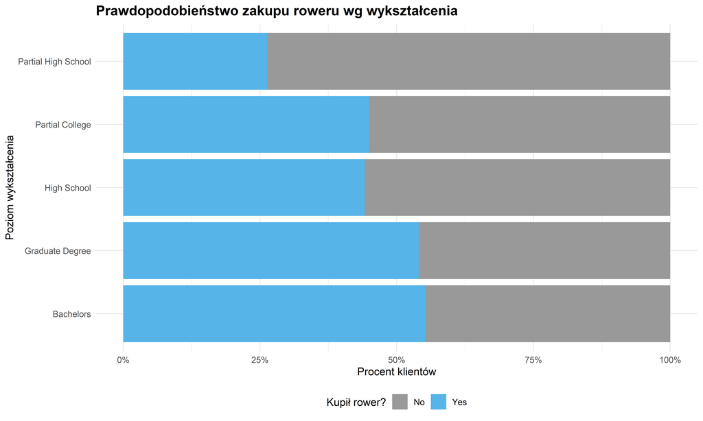

Wykres pokazuje, że najwyższy udział kupujących rower występuje wśród osób z wykształceniem wyższym, natomiast klienci z niższym wykształceniem rzadziej decydują się na zakup.

## Pytanie 2: Stan posiadania i styl życia (Samochody, Dojazdy)

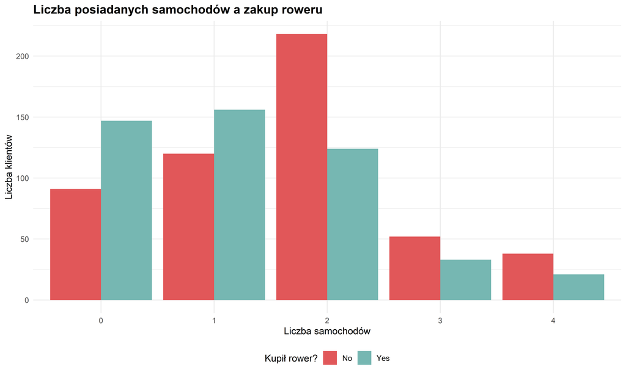

Widzimy, że klienci bez samochodu lub posiadający tylko jeden częściej kupują rower, a wraz ze wzrostem liczby aut w gospodarstwie udział kupujących wyraźnie spada.

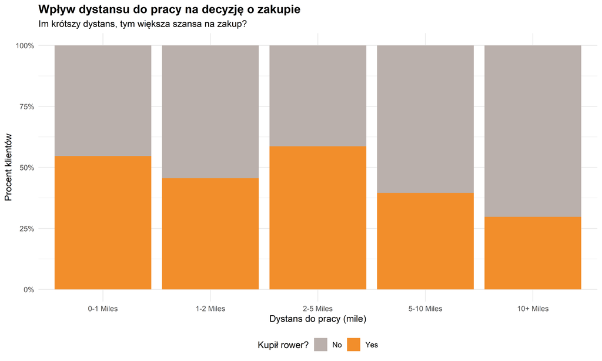

Krótszy dystans do pracy niekoniecznie wiąże się z wyższym odsetkiem kupujących rower na poziomie ogólnym, natomiast przy dużych odległościach wyraźnie rośnie udział osób, które roweru nie kupują.

## Pytanie 3: Różnice regionalne i wiekowe

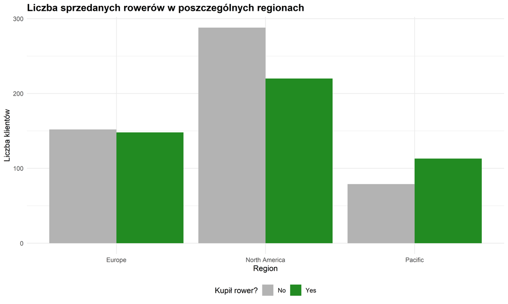

Między regionami widać wyraźne różnice w sprzedaży – w jednym z regionów liczba klientów kupujących rower jest zdecydowanie wyższa niż w pozostałych.

[figure not shown]

Heatmapa pokazuje, że zależność między dystansem do pracy a zakupem roweru jest silnie zróżnicowana regionalnie – w niektórych regionach krótkie dojazdy wiążą się z wysokim udziałem kupujących, podczas gdy w innych nawet przy podobnych odległościach odsetek zakupów pozostaje niski.